# Assignment 1: Task 1

Sophia Leiker

1/16/2022

```r
knitr::opts_chunk$set(echo = TRUE, warning=FALSE, message=FALSE)

library(tidyverse)
library(here)
library(janitor)
library(lubridate)
library(patchwork)
library(cowplot)
```

## 1. Introduction

This report will explore amphibian abundance data recorded by the Sierra Lakes Inventory Project. From the Environmental Data Initiative repository: “The Sierra Lakes Inventory Project (SLIP) was a research endeavor that ran from 1995-2002 and has supported research and management of Sierra Nevada aquatic ecosystems and their terrestrial interfaces. We described the physical characteristics of and surveyed aquatic communities for >8,000 lentic water bodies in the southern Sierra Nevada, including lakes, ponds, marshes, and meadows.”

The data used comes from: [Sierra Amphibians Dataset](https://doi.org/10.6073/pasta/d835832d7fd00d9e4466e44eea87fab3) and metadata, including methods used for data collection can be found here [The Sierra Lakes Inventory Project: Non-Native fish and community composition of lakes and ponds in the Sierra Nevada, California](https://portal.edirepository.org/nis/metadataviewer?packageid=edi.577.2).

```r
# Reading in the data
sierra <- read_csv(here("data", "sierra_amphibians.csv")) %>%
  clean_names()
```

# Part 1

## A. Data Wrangling

- Selecting Mountain yellow-legged frog (Rana muscosa) –> RAMU
- Finding count each year across all water bodies by life stage
- Exclude ‘EggMass’ level (find the total number of adult, subadult, and tadpole yellow-legged frogs observed in the entire study region by life stage and year)

```r
# filtering to only include certain species of interest
#using lubricate to change survery_date to an actual date
#only selecting adult, subadult and tadpole

sierra_yellow <- sierra %>%
  filter(amphibian_species %in% c("RAMU")) %>%
  mutate(survey_date = mdy(survey_date)) %>%
  mutate(survey_date = year(survey_date)) %>%
  filter(amphibian_life_stage %in% c("SubAdult", "Tadpole", "Adult"))
```

## B. Data Analysis

- Grouping by life stage and survey date

```r
sierra_count <- sierra_yellow %>%
  group_by(amphibian_life_stage, survey_date) %>%
  summarize(total_count = n())

#head(sierra_count)
```

## C. Data visualization

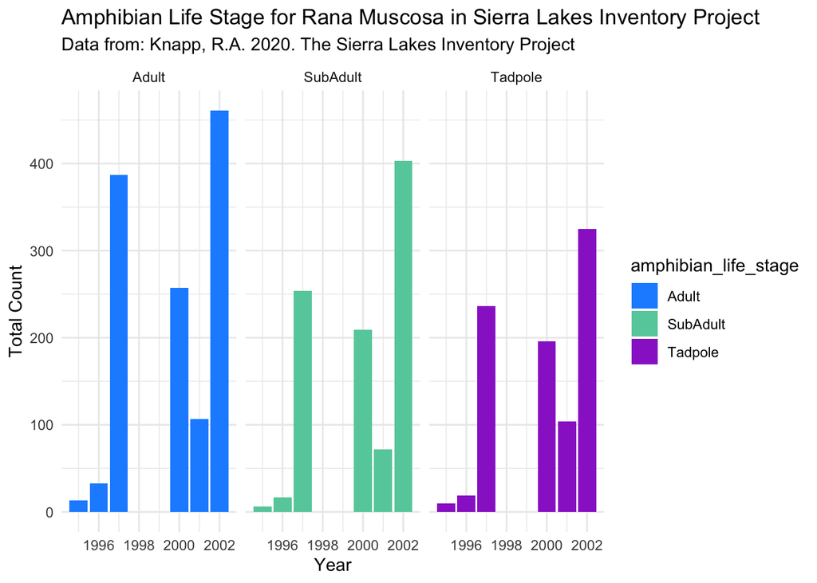

```r
graph1 <- ggplot(data = sierra_count, aes(x=survey_date, y= total_count, fill= amphibian_life_stage)) +
  geom_col() +
  labs(x = "Year", y = "Total Count", title = "Amphibian Life Stage for Rana Muscosa in Sierra Lakes Inventory Project", subtitle = "Data from: Knapp, R.A. 2020. The Sierra Lakes Inventory Project") +
  scale_color_manual(values = c("skyblue1","slateblue1","royalblue4")) +
  facet_wrap(~ amphibian_life_stage) +
  theme_minimal() +
  scale_fill_discrete(name = "Life Stage") +
  scale_fill_manual(values = c("dodgerblue1", "mediumaquamarine", "darkorchid3"))

graph1
```

**Figure 1**. Amphibian life stage of Rana Muscosa from 1995 to 2002 broken down by life stage

# Part 2

## A. Data Analysis

- Total counts of combined adult and sub-adult frogs in the 5 lakes with greatest total counts
- 5 columns with lake ID

```r
sierra_yellow2 <- sierra_yellow %>%
  filter(amphibian_life_stage %in% c("SubAdult", "Adult")) %>%
  group_by(lake_id) %>%
  summarize(total_count = n())

sierra_top5 <- sierra_yellow2 %>%
  slice_max(total_count, n = 5) %>% #the 6th value is lower than the 5th, so there are no ties between the 5th/6th
  arrange(desc(total_count)) %>%
  mutate(lake_id = as.character(lake_id))

# Adding "Lake" to the beginning of all the lake names
sierra_top5[1, "lake_id"] <- "Lake 50183"
sierra_top5[2, "lake_id"] <- "Lake 70583"
sierra_top5[3, "lake_id"] <- "Lake 10226"
sierra_top5[4, "lake_id"] <- "Lake 41322"
sierra_top5[5, "lake_id"] <- "Lake 50219"
```

## B. Data Visualization

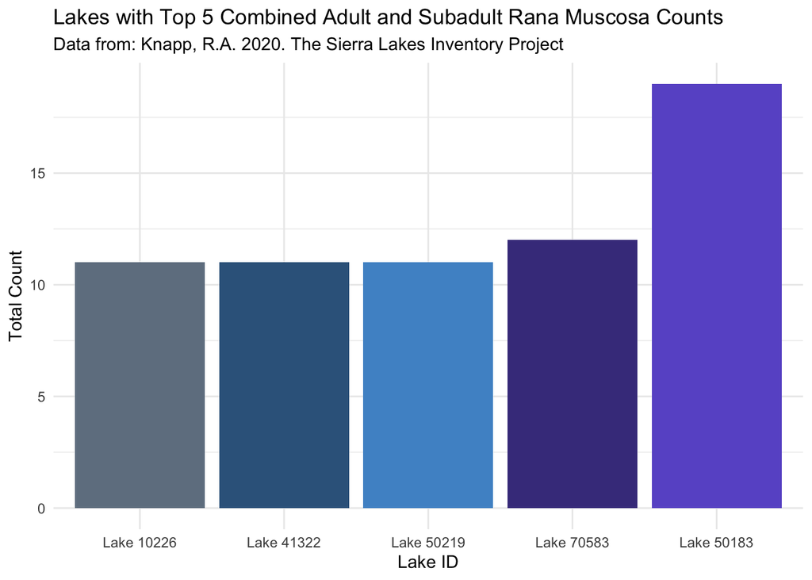

```r
graph2 <- ggplot(data = sierra_top5, aes(x= fct_reorder(lake_id, total_count), y = total_count)) +
  geom_col(aes(fill = lake_id)) +
  labs(x = 'Lake ID', y = 'Total Count') +
  #coord_flip() + #flips so columns go from vertical alignment to horizontal alginment
  theme_minimal() +
  theme(legend.position = "none") +
  labs(x = "Lake ID", y = "Total Count", title = "Lakes with Top 5 Combined Adult and Subadult Rana Muscosa Counts", subtitle = "Data from: Knapp, R.A. 2020. The Sierra Lakes Inventory Project") +
  scale_fill_manual(values = c("slategrey", "steelblue4", "slateblue", "steelblue3", "slateblue4"))

graph2
```

**Figure 2**. Lakes from The Sierra Lakes Inventory Project the with Top 5 Total Observed Counts of Combined Adult and Subadult Rana Muscosa

# Part 3 : Combine Graphs!

- Using `cowplot` to combine graph 1 and graph 2

## Assessment of Rana Muscosa Across by Life Stage, Year and Lake

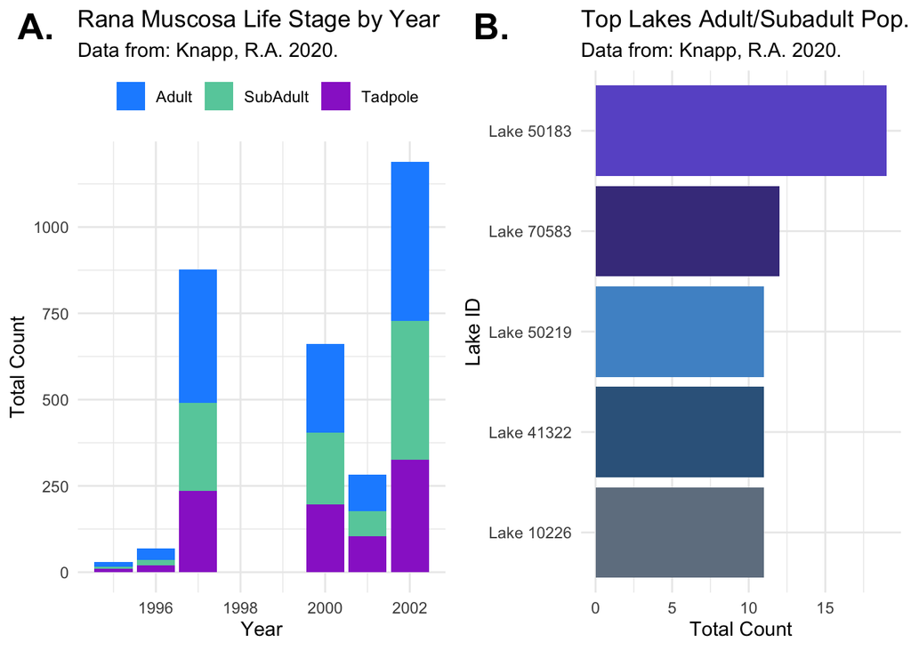

```r
#editing graphs to change the placement of things and remove subtitles
graph3 <- graph1 <- ggplot(data = sierra_count, aes(x=survey_date, y= total_count, fill= amphibian_life_stage)) +
  geom_col() +
  labs(x = "Year", y = "Total Count", title = "Rana Muscosa Life Stage by Year", subtitle = "Data from: Knapp, R.A. 2020.") +
  scale_color_manual(values = c("skyblue1","slateblue1","royalblue4")) +
  #facet_wrap(~ amphibian_life_stage) +
  theme_minimal() +
  scale_fill_discrete(name = "Life Stage") +
  scale_fill_manual(values = c("dodgerblue1", "mediumaquamarine", "darkorchid3")) +
  theme(legend.position = "top") +
  theme(legend.title = element_blank())

# NOTE: I am keeping the cord flip here as to allow space to see the full lake ID without them getting compressed
# I acknolege that changing the "total count" from vertical to hortizontal is not quite ideal
graph4 <- ggplot(data = sierra_top5, aes(x= fct_reorder(lake_id, total_count), y = total_count)) +
  geom_col(aes(fill = lake_id)) +
  labs(x = 'Lake ID', y = 'Total Count') +
  coord_flip() + #flips so columns go from vertical alignment to horizontal alginment
  theme_minimal() +
  theme(legend.position = "none") +
  labs(x = "Lake ID", y = "Total Count", title = "Top Lakes Adult/Subadult Pop.", subtitle = "Data from: Knapp, R.A. 2020.") +
  scale_fill_manual(values = c("slategrey", "steelblue4", "slateblue", "steelblue3", "slateblue4"))


plot_grid(graph3, graph4, labels = c("A.", "B."), label_size = 20)
```

## 4. Data Citation

Knapp, R.A., C. Pavelka, E.E. Hegeman, and T.C. Smith. 2020. The Sierra Lakes Inventory Project: Non-Native fish and community composition of lakes and ponds in the Sierra Nevada, California ver 2. Environmental Data Initiative. https://doi.org/10.6073/pasta/d835832d7fd00d9e4466e44eea87fab3